# Tugas UTS Metode Numeris

```
Nama : Fauzan Abdillah
NIM  : 19/444049/TK/49245
Prodi: Teknologi Informasi
```

## Analisis Numeris untuk Menentukan Laju Pertumbuhan Infeksi COVID-19

## Persiapan

Data yang akan dipakai bersumber dari https://www.worldometers.info/coronavirus/

### Inisiasi Pustaka

```python
import numpy as np
import matplotlib.pyplot as plt
from bs4 import BeautifulSoup
import requests
import re
import ast
```

Digunakan metode Scrapping untuk mengambil data dari sumber. Berikut ini source code untuk scrapping data yang digunakan:

```python
def scrap(id):
    try:
        r = requests.get("https://www.worldometers.info/coronavirus/country/"+id)
        soup = BeautifulSoup(r.text, 'lxml')
        s = soup.find(id="graph-active-cases-total").next_element.next_element
        x = re.search("[\n\r].*xAxis:\s*(.*\s*categories:\s*\[)([^]]*)", s.text)
        x = ast.literal_eval('['+x.group(2)+']')
        y = re.search("[\n\r].*data:\s*([\[])([^]]*)", s.text)
        y = ast.literal_eval('['+y.group(2)+']')

        s = soup.find(id="coronavirus-deaths-log").next_element.next_element.next_element.next_element.next_element.next_element
        p = re.search("[\n\r].*xAxis:\s*(.*\s*categories:\s*\[)([^]]*)", s.text)
        p = ast.literal_eval('['+p.group(2)+']')
        q = re.search("[\n\r].*data:\s*([\[])([^]]*)", s.text)
        q = ast.literal_eval('['+q.group(2)+']')

        # Pembatasan Data
        batasX = x.index('Mar 26')+1
        batasP = p.index('Mar 26')+1

        return x[:batasX], y[:batasX], p[:batasP], q[:batasP]
    except:
        print("Error {}".format(id))
```

Kemudian, berikut ini fungsi get_data yang akan dipakai untuk mengambil data suatu negara tertentu

```python
def get_data(id, name):
    x,y,p,q = scrap(id)
    country_data = {'name': name, 'active_cases':{}, 'death_cases':{}, 'active_datenumber' : [], 'death_datenumber' : []}
    country_data['active_cases']['x'] = np.array(x)
    country_data['active_cases']['y'] = np.array(y)
    country_data['death_cases']['x'] = np.array(p)
    country_data['death_cases']['y'] = np.array(q)

    for i, values in enumerate(country_data['active_cases']['x']):
        country_data['active_datenumber'].append(i+1)
    country_data['active_datenumber'] = np.array(country_data['active_datenumber'])

    for i, values in enumerate(country_data['death_cases']['x']):
        country_data['death_datenumber'].append(i+1)
    country_data['death_datenumber'] = np.array(country_data['death_datenumber'])
    return country_data
```

### Rumus Regresi Berpangkat

Membuat fungsi regresi berpangkat berdasarkan rumus berikut:

1. Linearisasi Persamaan Berpangkat

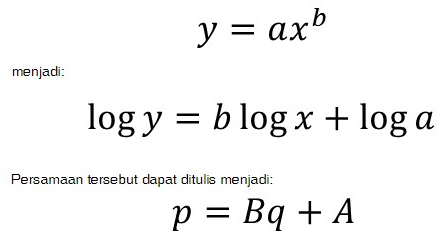

1. Menghitung Regresi Linearnya

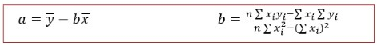

1. Mengembalikan ke bentuk persamaan berpangkat
1. Menghitung Koefisien Korelasi

Rumus-rumus tersebut diimplementasikan pada satu fungsi yang akan mengeluarkan nilai persamaan regresi dan koefisien korelasinya.

```python
def regresi_berpangkat(x, y):
    # Linearisasi Persamaan Berpangkat
#     p = np.log10(y)
    with np.errstate(divide='ignore'):
        p = np.where(y>0.01, np.log10(y), 0)
    q = np.where(x>0.01, np.log10(x), 0)
    # Mencari koefisien persamaan
    n = len(q)
    pq = p*q
    qq = q**2
    B = (n*pq.sum()-q.sum()*p.sum())/(n*qq.sum()-(q.sum())**2)
    A = p.mean() - (B * q.mean())
    # Membentuk persamaan berpangkat
    a = 10**A
    b = B
    persamaan_berpangkat = "y = {}(x^({}))".format(a,b)
    def fungsi(x, koef1=a, koef2=b):
        return koef1*(x**koef2)
    # Koefisien Korelasi
    yDt = (y - y.mean())**2
    yD = (y - a*(x**b))**2
    r = np.sqrt(abs((yDt.sum()-yD.sum())/yDt.sum()))
    xreg = np.array(range(x[0]*10,(x[-1]+1)*10))
    xreg = xreg/10
    yreg = fungsi(xreg, a, b)

    # Hasil
    hasil = {'persamaan': persamaan_berpangkat, 'koefisien_korelasi': r, 'perhitungan':fungsi, 'a': a, 'b':b, 'xreg': xreg, 'yreg': yreg}
    return hasil
```

Kemudian, saya membuat fungsi split untuk regresi berpangkat ini agar nantinya mudah membagi regresi antara data saat naik dan data saat turun.

```python
def regresi_aktif_berpangkat(country, when=None, batas=None):
    if when == None and batas == None:
        regresi = regresi_berpangkat(country['active_datenumber'], country['active_cases']['y'])
        print("""=== Persamaan Regresi Berpangkat pada Active Cases di {} ===
        Persamaan Regresi = {}
        Koefisien Korelasi = {}""".format(country['name'], regresi['persamaan'], regresi['koefisien_korelasi']))
        plot_active_data(country, regresi['xreg'], regresi['yreg'])
        return {'persamaan':regresi['persamaan'], 'koefisien_korelasi':regresi['koefisien_korelasi'], 'fungsi':regresi['perhitungan']}

    else:
        batas_data_country = np.where(country['active_cases']['x'] == batas)
        batas_country = int(batas_data_country[0])+1

        if when == 'before':
            regresi_sebelum = regresi_berpangkat(country['active_datenumber'][:batas_country], country['active_cases']['y'][:batas_country])
            print("""=== Persamaan Regresi Berpangkat pada Active Cases sebelum {} di {} ===
            Persamaan Regresi = {}
            Koefisien Korelasi = {}""".format(batas, country['name'], regresi_sebelum['persamaan'], regresi_sebelum['koefisien_korelasi']))
            plot_active_data(country, regresi_sebelum['xreg'], regresi_sebelum['yreg'], batasBawah=batas_country)
            return {'persamaan':regresi_sebelum['persamaan'], 'koefisien_korelasi':regresi_sebelum['koefisien_korelasi'], 'fungsi':regresi_sebelum['perhitungan']}
        elif when == 'after':
            regresi_setelah = regresi_berpangkat(country['active_datenumber'][batas_country:], country['active_cases']['y'][batas_country:])
            print("""=== Persamaan Regresi Berpangkat pada Active Cases setelah {} di {} ===
            Persamaan Regresi = {}
            Koefisien Korelasi = {}""".format(batas, country['name'], regresi_setelah['persamaan'], regresi_setelah['koefisien_korelasi']))
            plot_active_data(country, regresi_setelah['xreg'], regresi_setelah['yreg'], batasAtas=batas_country)
            return {'persamaan':regresi_setelah['persamaan'], 'koefisien_korelasi':regresi_setelah['koefisien_korelasi'], 'fungsi': regresi_setelah['perhitungan']}

def regresi_death_berpangkat(country, when=None, batas=None):
    if when == None and batas == None:
        regresi = regresi_berpangkat(country['death_datenumber'], country['death_cases']['y'])
        print("""=== Persamaan Regresi Berpangkat pada Death Cases di {} ===
        Persamaan Regresi = {}
        Koefisien Korelasi = {}""".format(country['name'], regresi['persamaan'], regresi['koefisien_korelasi']))
        plot_death_data(country, regresi['xreg'], regresi['yreg'])
        return {'persamaan':regresi['persamaan'], 'koefisien_korelasi':regresi['koefisien_korelasi'], 'fungsi': regresi['perhitungan']}
    else:
        batas_data_country = np.where(country['death_cases']['x'] == batas)
        batas_country = int(batas_data_country[0])+1

        if when == 'before':
            regresi_sebelum = regresi_berpangkat(country['death_datenumber'][:batas_country], country['death_cases']['y'][:batas_country])
            print("""=== Persamaan Regresi Berpangkat pada Death Cases sebelum {} di {} ===
            Persamaan Regresi = {}
            Koefisien Korelasi = {}""".format(batas, country['name'], regresi_sebelum['persamaan'], regresi_sebelum['koefisien_korelasi']))
            plot_death_data(country, regresi_sebelum['xreg'], regresi_sebelum['yreg'], batasBawah=batas_country)
            return {'persamaan':regresi_sebelum['persamaan'], 'koefisien_korelasi':regresi_sebelum['koefisien_korelasi'], 'fungsi': regresi_sebelum['perhitungan']}
        elif when == 'after':
            regresi_setelah = regresi_berpangkat(country['death_datenumber'][batas_country:], country['death_cases']['y'][batas_country:])
            print("""=== Persamaan Regresi Berpangkat pada death Cases setelah {} di {} ===
            Persamaan Regresi = {}
            Koefisien Korelasi = {}""".format(batas, country['name'], regresi_setelah['persamaan'], regresi_setelah['koefisien_korelasi']))
            plot_death_data(country, regresi_setelah['xreg'], regresi_setelah['yreg'], batasAtas=batas_country)
            return {'persamaan':regresi_setelah['persamaan'], 'koefisien_korelasi':regresi_setelah['koefisien_korelasi'], 'fungsi': regresi_setelah['perhitungan']}
```

### Rumus Regresi Eksponensial

Membuat fungsi persamaan regresi eksponensial berdasarkan rumus berikut:

1. Linearisasi Persamaan Eksponensial

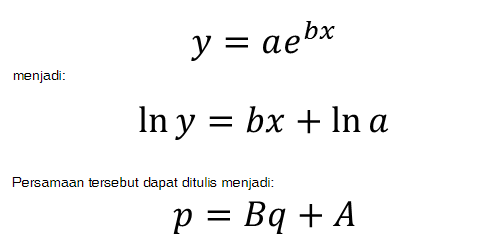

1. Menghitung Regresi Linear

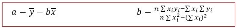

1. Mengembalikan ke bentuk persamaan berpangkat
1. Menghitung koefisien korelasi

Berdasarkan tahap-tahap tersebut, dibuat fungsi yang akan menghasilkan persamaan regresi ekponensial berikut:

```python
def regresi_eksponensial(x,y):
    # Linearisasi persamaan eksponensial
    with np.errstate(divide='ignore'):
        p = np.where(y>0.0000001, np.log(y), 0)
    q = x
    # Menghitung regresi linear
    n = len(q)
    pq = p*q
    qq = q**2
    # Membentuk persamaan eksponensial
    B = (n*pq.sum() - (q.sum()*p.sum()))/((n*qq.sum()) - ((q.sum())**2))
    A = p.mean() - B*q.mean()
    a = np.e**A
    b = B
    persamaan_eksponensial = "y = {:.4f}e^({:.4f}x)".format(a,b)
    def fungsi(x, koef1=a, koef2=b):
        return koef1*(np.e**(koef2*x))
    # Koefisien korelasi
    yDt = (y-y.mean())**2
    yD = (y - fungsi(x, a, b))**2
    r = np.sqrt(abs(yDt.sum()-yD.sum())/yDt.sum())
#     xreg = np.array(range(x[0]*10,(x[-1]*10)))
    xreg = x
    yreg = fungsi(xreg, a, b)
    # Hasil
    hasil = {'persamaan': persamaan_eksponensial, 'koefisien_korelasi': r, 'perhitungan':fungsi, 'a': a, 'b':b, 'xreg': xreg, 'yreg': yreg}
    return hasil
```

Kemudian, saya membuat fungsi split untuk regresi berpangkat ini agar nantinya mudah membagi regresi antara data saat naik dan data saat turun.

```python
def regresi_aktif_eksponensial(country, when=None, batas=None):
    if when == None and batas == None:
        regresi = regresi_eksponensial(country['active_datenumber'], country['active_cases']['y'])
        print("""=== Persamaan Regresi Eksponensial pada Active Cases di {} ===
        Persamaan Regresi = {}
        Koefisien Korelasi = {}""".format(country['name'], regresi['persamaan'], regresi['koefisien_korelasi']))
        plot_active_data(country, regresi['xreg'], regresi['yreg'])
        return {'persamaan':regresi['persamaan'], 'koefisien_korelasi':regresi['koefisien_korelasi'], 'fungsi': regresi['perhitungan']}
    else:
        batas_data_country = np.where(country['active_cases']['x'] == batas)
        batas_country = int(batas_data_country[0])+1

        if when == 'before':
            regresi_sebelum = regresi_eksponensial(country['active_datenumber'][:batas_country], country['active_cases']['y'][:batas_country])
            # Pengaman
            if regresi_sebelum['koefisien_korelasi'] > 1:
                while regresi_sebelum['koefisien_korelasi'] > 1:
                    batas_country = batas_country - 1
                    regresi_sebelum = regresi_eksponensial(country['active_datenumber'][:batas_country], country['active_cases']['y'][:batas_country])
                print("Peringatan! terjadi keanehan data, sehingga koefisien korelasi lebih dari satu.\nOleh karena itu, batas digeser ke {}".format(country['active_cases']['x'][batas_country-1]))
            print("""=== Persamaan Regresi Eksponensial pada Active Cases sebelum {} di {} ===
            Persamaan Regresi = {}
            Koefisien Korelasi = {}""".format(batas, country['name'], regresi_sebelum['persamaan'], regresi_sebelum['koefisien_korelasi']))
            plot_active_data(country, regresi_sebelum['xreg'], regresi_sebelum['yreg'], batasBawah=batas_country)
            return {'persamaan':regresi_sebelum['persamaan'], 'koefisien_korelasi':regresi_sebelum['koefisien_korelasi'], 'fungsi': regresi_sebelum['perhitungan']}
        elif when == 'after':
            regresi_setelah = regresi_eksponensial(country['active_datenumber'][batas_country:], country['active_cases']['y'][batas_country:])
            print("""=== Persamaan Regresi Eksponensial pada Active Cases setelah {} di {} ===
            Persamaan Regresi = {}
            Koefisien Korelasi = {}""".format(batas, country['name'], regresi_setelah['persamaan'], regresi_setelah['koefisien_korelasi']))
            plot_active_data(country, regresi_setelah['xreg'], regresi_setelah['yreg'], batasAtas=batas_country)
            return {'persamaan':regresi_setelah['persamaan'], 'koefisien_korelasi':regresi_setelah['koefisien_korelasi'], 'fungsi': regresi_setelah['perhitungan']}

def regresi_death_eksponensial(country, when=None, batas=None):
    if when == None and batas == None:
        regresi = regresi_eksponensial(country['death_datenumber'], country['death_cases']['y'])
        print("""=== Persamaan Regresi Eksponensial pada Death Cases di {} ===
        Persamaan Regresi = {}
        Koefisien Korelasi = {}""".format(country['name'], regresi['persamaan'], regresi['koefisien_korelasi']))
        plot_death_data(country, regresi['xreg'], regresi['yreg'])
        return {'persamaan':regresi['persamaan'], 'koefisien_korelasi':regresi['koefisien_korelasi'], 'fungsi': regresi['perhitungan']}

    else:
        batas_data_country = np.where(country['death_cases']['x'] == batas)
        batas_country = int(batas_data_country[0])+1

        if when == 'before':
            regresi_sebelum = regresi_eksponensial(country['death_datenumber'][:batas_country], country['death_cases']['y'][:batas_country])
            print("""=== Persamaan Regresi Eksponensial pada Death Cases sebelum {} di {} ===
            Persamaan Regresi = {}
            Koefisien Korelasi = {}""".format(batas, country['name'], regresi_sebelum['persamaan'], regresi_sebelum['koefisien_korelasi']))
            plot_death_data(country, regresi_sebelum['xreg'], regresi_sebelum['yreg'], batasBawah=batas_country)
            return {'persamaan':regresi_sebelum['persamaan'], 'koefisien_korelasi':regresi_sebelum['koefisien_korelasi'], 'fungsi': regresi_sebelum['perhitungan']}
        elif when == 'after':
            regresi_setelah = regresi_eksponensial(country['death_datenumber'][batas_country:], country['death_cases']['y'][batas_country:])
            print("""=== Persamaan Regresi Eksponensial pada Death Cases setelah {} di {} ===
            Persamaan Regresi = {}
            Koefisien Korelasi = {}""".format(batas, country['name'], regresi_setelah['persamaan'], regresi_setelah['koefisien_korelasi']))
            plot_death_data(country, regresi_setelah['xreg'], regresi_setelah['yreg'], batasAtas=batas_country)
            return {'persamaan':regresi_setelah['persamaan'], 'koefisien_korelasi':regresi_setelah['koefisien_korelasi'], 'fungsi': regresi_setelah['perhitungan']}
```

### Rumus Regresi Polinomial

Berikutnya, saya membuat fungsi regresi polinomial berdasarkan rumus-rumus dan tahap-tahap berikut:

1. Membuat matriks untuk mengetahui koefisien - koefisien dari persamaan polinomialnya. Matriksnya berbentuk sebagai berikut:

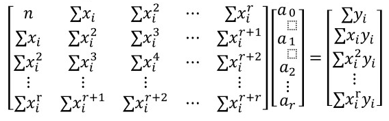

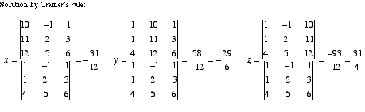

1. Setelah persamaan polinomial terbentuk, dicari nilai dari koefisien korelasinya.

Berikut source code untuk menghasilkan fungsi polinomialnya:

```python
def regresi_polinomial(x,y):

    # Mendaftarkan elemen matriks
    n = len(x)
    sx1 = x.sum()
    sx2 = (x**2).sum()
    sx3 = (x**3).sum()
    sx4 = (x**4).sum()
    sx5 = (x**5).sum()
    sx6 = (x**6).sum()
    sy = y.sum()
    sxy = (x*y).sum()
    sx2y = ((x**2)*y).sum()
    sx3y = ((x**3)*y).sum()

    # Memasang elemen pada matriks
    A=[[n, sx1, sx2, sx3],[sx1, sx2, sx3, sx4],[sx2, sx3, sx4, sx5],[sx3, sx4, sx5, sx6]]
    B=[sy, sxy, sx2y, sx3y]
    C=[[n, sx1, sx2, sx3],[sx1, sx2, sx3, sx4],[sx2, sx3, sx4, sx5],[sx3, sx4, sx5, sx6]]

    # Membuat matriks X berisi keempat koefisien
    X = []
    for i in range(0,len(B)):
        for j in range(0,len(B)):
            C[j][i]=B[j]
            if i>0:
                C[j][i-1]=A[j][i-1]
        X.append(np.linalg.det(C)/np.linalg.det(A))

    # membuat fungsi regresi, terdiri dari koefisien yang telah terbentuk
    def fungsi(x):
        return X[0] + (X[1]*x) + (X[2]*(x**2)) + (X[3]*(x**3))

    # menghitung koefisien korelasi
    yDt = (y - y.mean())**2
    yD = (y - fungsi(x))**2

    r = np.sqrt(abs((yDt.sum()-yD.sum())/yDt.sum()))

    xreg =x
    yreg =fungsi(xreg)

    persamaan_polinomial = "y = {:.4f} + ({:.4f})x + ({:.4f})x^2 + ({:.4f})x^3 ".format(X[0],X[1],X[2],X[3])
    hasil = {'persamaan': persamaan_polinomial, 'koefisien_korelasi': r, 'perhitungan':fungsi, 'xreg':xreg, 'yreg':yreg, 'p':X[0], 'q':X[1], 'r':X[2], 's':X[3]}
    return hasil
```

```python
def regresi_aktif_polinomial(country, when=None, batas=None):
    if when == None and batas == None:
        regresi = regresi_polinomial(country['active_datenumber'], country['active_cases']['y'])
        print("""=== Persamaan Regresi Polinomial pada Active Cases di {} ===
        Persamaan Regresi = {}
        Koefisien Korelasi = {}""".format(country['name'], regresi['persamaan'], regresi['koefisien_korelasi']))
        plot_active_data(country, regresi['xreg'], regresi['yreg'])
        return {'persamaan':regresi['persamaan'], 'koefisien_korelasi':regresi['koefisien_korelasi'], 'fungsi': regresi['perhitungan']}
    else:
        batas_data_country = np.where(country['active_cases']['x'] == batas)
        batas_country = int(batas_data_country[0])+1

        if when == 'before':
            regresi_sebelum = regresi_polinomial(country['active_datenumber'][:batas_country], country['active_cases']['y'][:batas_country])
            # Pengaman
            if regresi_sebelum['koefisien_korelasi'] > 1:
                while regresi_sebelum['koefisien_korelasi'] > 1:
                    batas_country = batas_country + 1
                    regresi_sebelum = regresi_polinomial(country['active_datenumber'][:batas_country], country['active_cases']['y'][:batas_country])
                print("Peringatan! terjadi keanehan data, sehingga koefisien korelasi lebih dari satu.\nOleh karena itu, batas digeser ke {}".format(country['active_cases']['x'][batas_country-1]))
            print("""=== Persamaan Regresi Polinomial pada Active Cases sebelum {} di {} ===
            Persamaan Regresi = {}
            Koefisien Korelasi = {}""".format(batas, country['name'], regresi_sebelum['persamaan'], regresi_sebelum['koefisien_korelasi']))
            plot_active_data(country, regresi_sebelum['xreg'], regresi_sebelum['yreg'], batasBawah=batas_country)
            return {'persamaan':regresi_sebelum['persamaan'], 'koefisien_korelasi':regresi_sebelum['koefisien_korelasi'], 'fungsi': regresi_sebelum['perhitungan']}
        elif when == 'after':
            regresi_setelah = regresi_polinomial(country['active_datenumber'][batas_country:], country['active_cases']['y'][batas_country:])
            # Pengaman
            if regresi_setelah['koefisien_korelasi'] > 1:
                while regresi_setelah['koefisien_korelasi'] > 1:
                    batas_country = batas_country + 1
                    regresi_setelah = regresi_polinomial(country['active_datenumber'][:batas_country], country['active_cases']['y'][:batas_country])
                print("Peringatan! terjadi keanehan data, sehingga koefisien korelasi lebih dari satu.\nOleh karena itu, batas digeser ke {}".format(country['active_cases']['x'][batas_country-1]))
            print("""=== Persamaan Regresi Polinomial pada Active Cases setelah {} di {} ===
            Persamaan Regresi = {}
            Koefisien Korelasi = {}""".format(batas, country['name'], regresi_setelah['persamaan'], regresi_setelah['koefisien_korelasi']))
            plot_active_data(country, regresi_setelah['xreg'], regresi_setelah['yreg'], batasAtas=batas_country)
            return {'persamaan':regresi_setelah['persamaan'], 'koefisien_korelasi':regresi_setelah['koefisien_korelasi'], 'fungsi': regresi_setelah['perhitungan']}

def regresi_death_polinomial(country, when=None, batas=None):
    if when == None and batas == None:
        regresi = regresi_polinomial(country['death_datenumber'], country['death_cases']['y'])
        print("""=== Persamaan Regresi Polinomial pada Death Cases di {} ===
        Persamaan Regresi = {}
        Koefisien Korelasi = {}""".format(country['name'], regresi['persamaan'], regresi['koefisien_korelasi']))
        plot_death_data(country, regresi['xreg'], regresi['yreg'])
        return {'persamaan':regresi['persamaan'], 'koefisien_korelasi':regresi['koefisien_korelasi'], 'fungsi': regresi['perhitungan']}

    else:
        batas_data_country = np.where(country['death_cases']['x'] == batas)
        batas_country = int(batas_data_country[0])+1

        if when == 'before':
            regresi_sebelum = regresi_polinomial(country['death_datenumber'][:batas_country], country['death_cases']['y'][:batas_country])
            # Pengaman
            if regresi_sebelum['koefisien_korelasi'] > 1:
                while regresi_sebelum['koefisien_korelasi'] > 1:
                    batas_country = batas_country + 1
                    regresi_sebelum = regresi_polinomial(country['death_datenumber'][:batas_country], country['death_cases']['y'][:batas_country])
                print("Peringatan! terjadi keanehan data, sehingga koefisien korelasi lebih dari satu.\nOleh karena itu, batas digeser ke {}".format(country['death_cases']['x'][batas_country-1]))
            print("""=== Persamaan Regresi Polinomial pada Death Cases sebelum {} di {} ===
            Persamaan Regresi = {}
            Koefisien Korelasi = {}""".format(batas, country['name'], regresi_sebelum['persamaan'], regresi_sebelum['koefisien_korelasi']))
            plot_death_data(country, regresi_sebelum['xreg'], regresi_sebelum['yreg'], batasBawah=batas_country)
            return {'persamaan':regresi_sebelum['persamaan'], 'koefisien_korelasi':regresi_sebelum['koefisien_korelasi'], 'fungsi': regresi_sebelum['perhitungan']}
        elif when == 'after':
            regresi_setelah = regresi_polinomial(country['death_datenumber'][batas_country:], country['death_cases']['y'][batas_country:])
            # Pengaman
            if regresi_setelah['koefisien_korelasi'] > 1:
                while regresi_setelah['koefisien_korelasi'] > 1:
                    batas_country = batas_country + 1
                    regresi_setelah = regresi_polinomial(country['death_datenumber'][:batas_country], country['death_cases']['y'][:batas_country])
                print("Peringatan! terjadi keanehan data, sehingga koefisien korelasi lebih dari satu.\nOleh karena itu, batas digeser ke {}".format(country['death_cases']['x'][batas_country-1]))
            print("""=== Persamaan Regresi Polinomial pada Death Cases setelah {} di {} ===
            Persamaan Regresi = {}
            Koefisien Korelasi = {}""".format(batas, country['name'], regresi_setelah['persamaan'], regresi_setelah['koefisien_korelasi']))
            plot_death_data(country, regresi_setelah['xreg'], regresi_setelah['yreg'], batasAtas=batas_country)
            return {'persamaan':regresi_setelah['persamaan'], 'koefisien_korelasi':regresi_setelah['koefisien_korelasi'], 'fungsi': regresi_setelah['perhitungan']}
```

### Fungsi untuk plotting Grafik

Kemudian, saya membuat fungsi untuk plotting grafik agar nantinya ketika hendak menggambar grafik tinggal memanggil fungsi ini.

```python
def plot_active_data(country, x=0, y=0, batasAtas=0, batasBawah=0):
    if batasBawah == 0 :
        batasBawah = len(country['active_cases']['x'])
    fig, ax = plt.subplots(figsize=(10, 6))

    what_to_plotted_X = np.array(range(batasAtas,batasBawah))
    what_to_plotted_Y = country['active_cases']['y'][batasAtas:batasBawah]

    ax.plot(what_to_plotted_X, what_to_plotted_Y, 'ro', label='Active Cases')
    if type(country['active_cases']['x'][batasAtas:batasBawah]) == type(x):
        ax.plot(x,y,'b', label='Regression Line')
    plt.legend(loc="lower right")
    plt.grid()
    plt.title('Grafik Active Case di '+country['name'])
    plt.xlabel('Tanggal')
    plt.ylabel('Active Case')
    ax.set_xticks(np.arange(batasAtas, batasBawah))
    ax.set_xticklabels(country['active_cases']['x'][batasAtas:batasBawah])
    plt.xticks(rotation=60)
    for i,label in enumerate(ax.xaxis.get_ticklabels()[1::2]):
        label.set_visible(False)
    plt.show()

def plot_death_data(country, x=0, y=0, batasAtas=0, batasBawah=0):
    if batasBawah == 0 :
        batasBawah = len(country['death_cases']['x'])
    fig, ax = plt.subplots(figsize=(10, 6))

    what_to_plotted_X = np.array(range(batasAtas,batasBawah))
    what_to_plotted_Y = country['death_cases']['y'][batasAtas:batasBawah]

    ax.plot(what_to_plotted_X, what_to_plotted_Y, 'ro', label='Death Cases')
    if type(country['death_cases']['x'][batasAtas:batasBawah]) == type(x):
        ax.plot(x,y,'b', label='Regression Line')
    plt.legend(loc="lower right")
    plt.grid()
    plt.title('Grafik Death Case di '+country['name'])
    plt.xlabel('Tanggal')
    plt.ylabel('Death Case')
    ax.set_xticks(np.arange(batasAtas, batasBawah))
    ax.set_xticklabels(country['death_cases']['x'][batasAtas:batasBawah])
    plt.xticks(rotation=60)
    for i,label in enumerate(ax.xaxis.get_ticklabels()[1::2]):
        label.set_visible(False)
    plt.show()
```

### Fungsi untuk menampilkan analisis kurva

Saya membuat fungsi untuk menampilkan persamaan kurva dan koefisien korelasinya, agar nantinya mudah dipanggil untuk keperluan analisis.

```python
def analisis(category, be_p, be_e, be_po, af_p=None, af_e=None, af_po=None, date=None):
    if date == None:
        print("=== {} Cases hingga 26 Maret 2020 ===".format(category))
        print("""
        -Persamaan Regresi-
        Regresi Berpangkat: {}
        Regresi Eksponensial: {}
        Regresi Polinomial orde 3: {}

        -Koefisien Korelasi-
        Regresi Berpangkat: {:.4f}
        Regresi Eksponensial: {:.4f}
        Regresi Polinomial orde 3: {:.4f}""".format(be_p['persamaan'], be_e['persamaan'], be_po['persamaan'], be_p['koefisien_korelasi'], be_e['koefisien_korelasi'], be_po['koefisien_korelasi']))

    else:
        print("=== {} Cases sebelum {} ===".format(category, date))
        print("""
        -Persamaan Regresi-
        Regresi Berpangkat: {}
        Regresi Eksponensial: {}
        Regresi Polinomial orde 3: {}

        -Koefisien Korelasi-
        Regresi Berpangkat: {:.4f}
        Regresi Eksponensial: {:.4f}
        Regresi Polinomial orde 3: {:.4f}""".format(be_p['persamaan'], be_e['persamaan'], be_po['persamaan'], be_p['koefisien_korelasi'], be_e['koefisien_korelasi'], be_po['koefisien_korelasi']))
        print()
        print("=== {} Cases sesudah {} hinga 26 Maret 2020 ===".format(category, date))
        print("""
        -Persamaan Regresi-
        Regresi Berpangkat: {}
        Regresi Eksponensial: {}
        Regresi Polinomial orde 3:`b {}

        -Koefisien Korelasi-
        Regresi Berpangkat: {:.4f}
        Regresi Eksponensial: {:.4f}
        Regresi Polinomial orde 3: {:.4f}""".format(af_p['persamaan'], af_e['persamaan'], af_po['persamaan'], af_p['koefisien_korelasi'], af_e['koefisien_korelasi'], af_po['koefisien_korelasi']))

# Variabel untuk menyimpan perwakilan kurva tiap negara
kurva_negara = {}
```

## 1. China

Negara pertama yang akan dianalisis adalah negara China. Oleh karena itu, kita panggil fungsi untuk mengambil data COVID-19 di China.

```python
china = get_data('china', 'Tiongkok')
```

### Active Cases

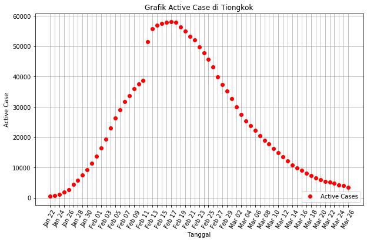

```python
plot_active_data(china)
```

Terlihat bahwa Active Cases naik hingga 17 Februari, kemudian mengalami penurunan. Oleh karena itu, kita pisahkan active cases sebelum 17 Februari dan Active Cases setelah 17 Februari

### Persamaan Regresi Berpangkat pada Active Cases

```
=== Persamaan Regresi Berpangkat pada Active Cases sebelum Feb 17 di Tiongkok ===
            Persamaan Regresi = y = 262.2287071662336(x^(1.6591802001040628))
            Koefisien Korelasi = 0.9898721075231579
```

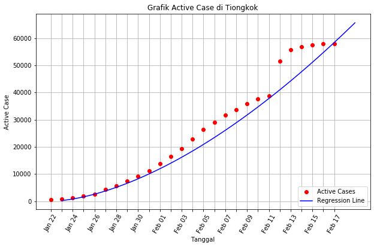

```
{'persamaan': 'y = 262.2287071662336(x^(1.6591802001040628))',
 'koefisien_korelasi': 0.9898721075231579,
 'fungsi': <function __main__.regresi_berpangkat.<locals>.fungsi(x, koef1=262.2287071662336, koef2=1.6591802001040628)>}
```

```python
china_ac_be_p = regresi_aktif_berpangkat(china, 'before', 'Feb 17')
china_ac_be_p
```

```
=== Persamaan Regresi Berpangkat pada Active Cases setelah Feb 17 di Tiongkok ===
            Persamaan Regresi = y = 10436441410.470179(x^(-3.48933748893684))
            Koefisien Korelasi = 0.8769693271179312
```

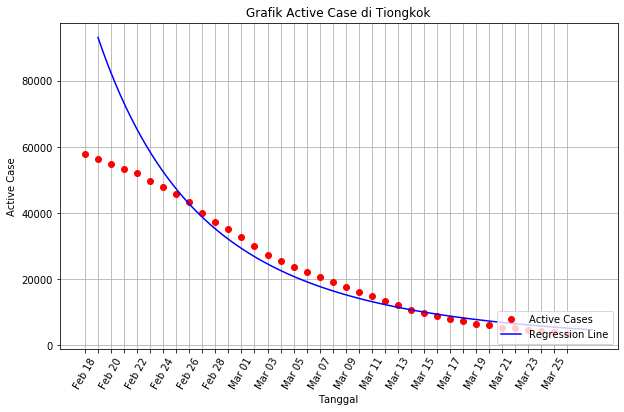

```
{'persamaan': 'y = 10436441410.470179(x^(-3.48933748893684))',
 'koefisien_korelasi': 0.8769693271179312,
 'fungsi': <function __main__.regresi_berpangkat.<locals>.fungsi(x, koef1=10436441410.470179, koef2=-3.48933748893684)>}
```

```python
china_ac_af_p = regresi_aktif_berpangkat(china, 'after', 'Feb 17')
china_ac_af_p
```

### Persamaan Regresi Eksponensial pada Active Cases di China

```
=== Persamaan Regresi Eksponensial pada Active Cases sebelum Feb 17 di Tiongkok ===
            Persamaan Regresi = y = 1326.6517e^(0.1676x)
            Koefisien Korelasi = 0.5190922195497654
```

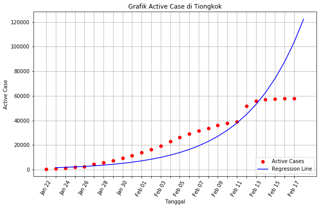

```
{'persamaan': 'y = 1326.6517e^(0.1676x)',
 'koefisien_korelasi': 0.5190922195497654,
 'fungsi': <function __main__.regresi_eksponensial.<locals>.fungsi(x, koef1=1326.6517221124482, koef2=0.16756689028354152)>}
```

```python
china_ac_be_e = regresi_aktif_eksponensial(china, 'before', 'Feb 17')
china_ac_be_e
```

```
=== Persamaan Regresi Eksponensial pada Active Cases setelah Feb 17 di Tiongkok ===
            Persamaan Regresi = y = 716045.9946e^(-0.0797x)
            Koefisien Korelasi = 0.9641172853336922
```

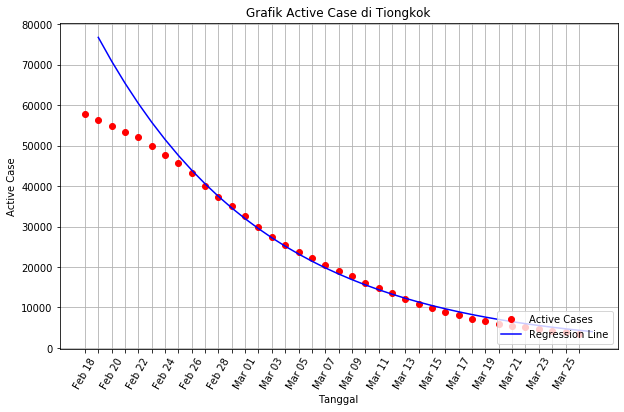

```
{'persamaan': 'y = 716045.9946e^(-0.0797x)',
 'koefisien_korelasi': 0.9641172853336922,
 'fungsi': <function __main__.regresi_eksponensial.<locals>.fungsi(x, koef1=716045.9945966284, koef2=-0.0797369797253486)>}
```

```python
china_ac_af_e = regresi_aktif_eksponensial(china, 'after', 'Feb 17')
china_ac_af_e
```

### Persamaan Regresi Polinomial (orde 3) pada Active Cases di China

```
Peringatan! terjadi keanehan data, sehingga koefisien korelasi lebih dari satu.
Oleh karena itu, batas digeser ke Feb 18
=== Persamaan Regresi Polinomial pada Active Cases sebelum Feb 17 di Tiongkok ===
            Persamaan Regresi = y = -6949.9668 + (2408.9955)x + (-47.7395)x^2 + (2.0078)x^3
            Koefisien Korelasi = 0.9843979432283544
```

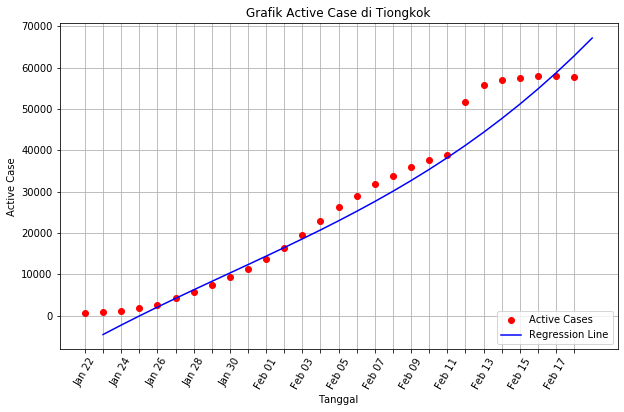

```
{'persamaan': 'y = -6949.9668 + (2408.9955)x + (-47.7395)x^2 + (2.0078)x^3 ',
 'koefisien_korelasi': 0.9843979432283544,
 'fungsi': <function __main__.regresi_polinomial.<locals>.fungsi(x)>}
```

```python
china_ac_be_po = regresi_aktif_polinomial(china, 'before', 'Feb 17')
china_ac_be_po
```

```
=== Persamaan Regresi Polinomial pada Active Cases setelah Feb 17 di Tiongkok ===
            Persamaan Regresi = y = 108063.4835 + (-2034.6005)x + (4.9137)x^2 + (-0.0010)x^3
            Koefisien Korelasi = 0.9812325634365296
```

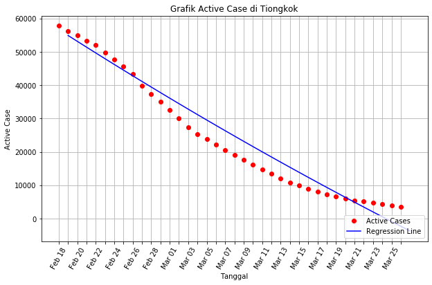

```
{'persamaan': 'y = 108063.4835 + (-2034.6005)x + (4.9137)x^2 + (-0.0010)x^3 ',
 'koefisien_korelasi': 0.9812325634365296,
 'fungsi': <function __main__.regresi_polinomial.<locals>.fungsi(x)>}
```

```python
china_ac_af_po = regresi_aktif_polinomial(china, 'after', 'Feb 17')
china_ac_af_po
```

### Analisis kurva-kurva regresi pada Active Cases di China

```python
analisis('Active', china_ac_be_p, china_ac_be_e, china_ac_be_po, china_ac_af_p, china_ac_af_e, china_ac_af_po, '17 Februari')
```

```
=== Active Cases sebelum 17 Februari ===

        -Persamaan Regresi-
        Regresi Berpangkat: y = 262.2287071662336(x^(1.6591802001040628))
        Regresi Eksponensial: y = 1326.6517e^(0.1676x)
        Regresi Polinomial orde 3: y = -6949.9668 + (2408.9955)x + (-47.7395)x^2 + (2.0078)x^3

        -Koefisien Korelasi-
        Regresi Berpangkat: 0.9899
        Regresi Eksponensial: 0.5191
        Regresi Polinomial orde 3: 0.9844

=== Active Cases sesudah 17 Februari hinga 26 Maret 2020 ===

        -Persamaan Regresi-
        Regresi Berpangkat: y = 10436441410.470179(x^(-3.48933748893684))
        Regresi Eksponensial: y = 716045.9946e^(-0.0797x)
        Regresi Polinomial orde 3:`b y = 108063.4835 + (-2034.6005)x + (4.9137)x^2 + (-0.0010)x^3

        -Koefisien Korelasi-
        Regresi Berpangkat: 0.8770
        Regresi Eksponensial: 0.9641
        Regresi Polinomial orde 3: 0.9812
```

```python
kurva_negara['china'] = {}
kurva_negara['china']['ac'] = china_ac_af_po
```

### Death Cases

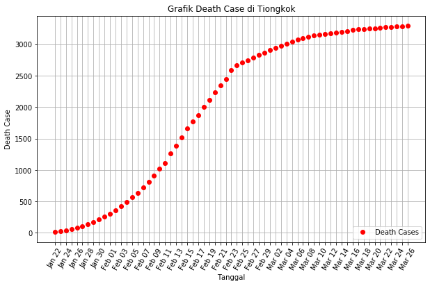

```python
plot_death_data(china)
```

Kenaikan data berubah mulai tanggal 23 Februari. Sehingga, regresi akan dibagi pada tanggal tersebut

### Persamaan Regresi Berpangkat pada Death Cases di Tiongkok

```
=== Persamaan Regresi Berpangkat pada Death Cases sebelum Feb 23 di Tiongkok ===
            Persamaan Regresi = y = 7.155972214758709(x^(1.6462563461718769))
            Koefisien Korelasi = 0.9817311189831716
```

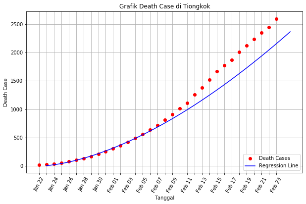

```python
china_dc_be_p = regresi_death_berpangkat(china, 'before', 'Feb 23')
```

```
=== Persamaan Regresi Berpangkat pada death Cases setelah Feb 23 di Tiongkok ===
            Persamaan Regresi = y = 916.3974521664856(x^(0.31253719394663365))
            Koefisien Korelasi = 0.9636381920798194
```

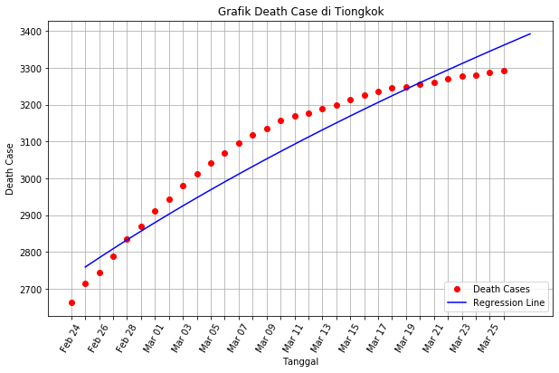

```python
china_dc_af_p = regresi_death_berpangkat(china, 'after', 'Feb 23')
```

### Persamaan Regresi Eksponensial pada Death Cases di Tiongkok

```
=== Persamaan Regresi Eksponensial pada Death Cases sebelum Feb 23 di Tiongkok ===
            Persamaan Regresi = y = 44.6897e^(0.1418x)
            Koefisien Korelasi = 0.6929116861817085
```

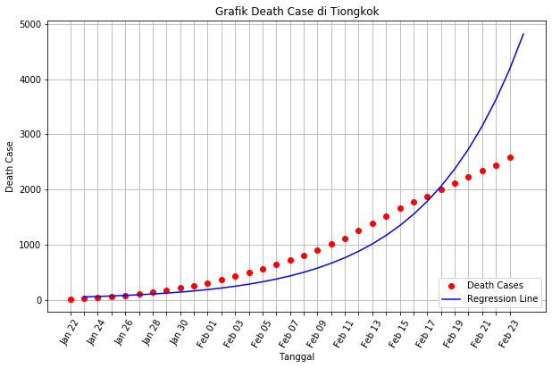

```python
china_dc_be_e = regresi_death_eksponensial(china, 'before', 'Feb 23')
```

```
=== Persamaan Regresi Eksponensial pada Death Cases setelah Feb 23 di Tiongkok ===
            Persamaan Regresi = y = 2258.3323e^(0.0063x)
            Koefisien Korelasi = 0.9378685914394426
```

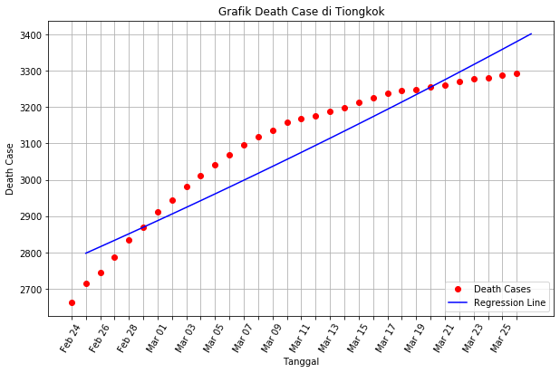

```python
china_dc_af_e = regresi_death_eksponensial(china, 'after', 'Feb 23')
```

### Persamaan Regresi Polinomial (orde 3) pada Death Cases di Tiongkok

```
=== Persamaan Regresi Polinomial pada Death Cases sebelum Feb 23 di Tiongkok ===
            Persamaan Regresi = y = -21.0823 + (6.9866)x + (2.2668)x^2 + (0.0001)x^3
            Koefisien Korelasi = 0.9987935960742222
```

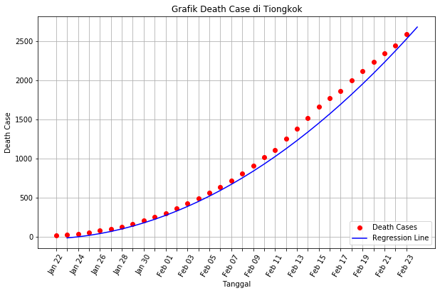

```python
china_dc_be_po = regresi_death_polinomial(china, 'before', 'Feb 23')
```

```
=== Persamaan Regresi Polinomial pada Death Cases setelah Feb 23 di Tiongkok ===
            Persamaan Regresi = y = 4522.9012 + (-80.3396)x + (1.0023)x^2 + (0.0000)x^3
            Koefisien Korelasi = 0.6834171820945885
```

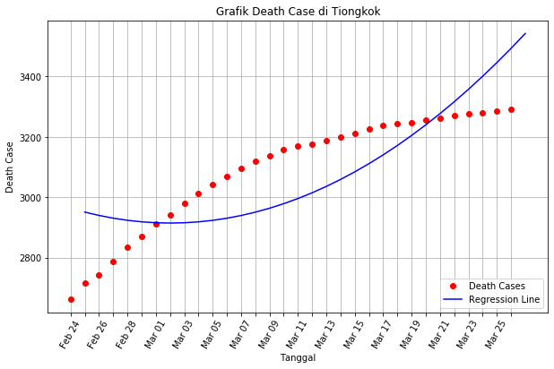

```python
china_dc_af_po = regresi_death_polinomial(china, 'after', 'Feb 23')
```

### Analisis kurva-kurva regresi pada Death Cases di China

```python
analisis('Death', china_dc_be_p, china_dc_be_e, china_dc_be_po, china_dc_af_p, china_dc_af_e, china_dc_af_po, '23 Februari')
```

```
=== Death Cases sebelum 23 Februari ===

        -Persamaan Regresi-
        Regresi Berpangkat: y = 7.155972214758709(x^(1.6462563461718769))
        Regresi Eksponensial: y = 44.6897e^(0.1418x)
        Regresi Polinomial orde 3: y = -21.0823 + (6.9866)x + (2.2668)x^2 + (0.0001)x^3

        -Koefisien Korelasi-
        Regresi Berpangkat: 0.9817
        Regresi Eksponensial: 0.6929
        Regresi Polinomial orde 3: 0.9988

=== Death Cases sesudah 23 Februari hinga 26 Maret 2020 ===

        -Persamaan Regresi-
        Regresi Berpangkat: y = 916.3974521664856(x^(0.31253719394663365))
        Regresi Eksponensial: y = 2258.3323e^(0.0063x)
        Regresi Polinomial orde 3:`b y = 4522.9012 + (-80.3396)x + (1.0023)x^2 + (0.0000)x^3

        -Koefisien Korelasi-
        Regresi Berpangkat: 0.9636
        Regresi Eksponensial: 0.9379
        Regresi Polinomial orde 3: 0.6834
```

Dari data diatas dapat disimpulkan bahwa:

1. Regresi polinomial orde 3 paling mewakili data Death Case sebelum 23 Februari di China
2. Regresi berpangkat mewakili data Death Case setelah 23 Februari di China

```python
kurva_negara['china']['dc'] = china_dc_af_p
```

## 2. Korea Selatan

```python
korsel = get_data('south-korea', 'Korea Selatan')
```

### Active Cases

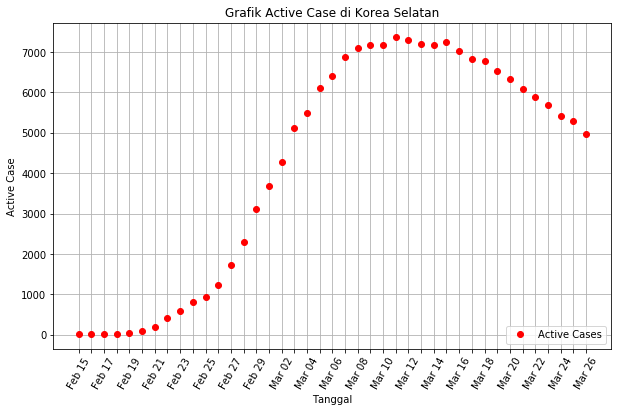

```python
plot_active_data(korsel)
```

Terlihat data mengalami penurunan mulai tanggal 11 Maret. Oleh karena itu, kita pisah regresi sebelum dan sesudah 11 Maret.

### Persamaan Regresi Berpangkat pada Active Cases di Korea Selatan

```
=== Persamaan Regresi Berpangkat pada Active Cases sebelum Mar 11 di Korea Selatan ===
            Persamaan Regresi = y = 2.58156288829746(x^(2.4909327586086443))
            Koefisien Korelasi = 0.9567358345544574
```

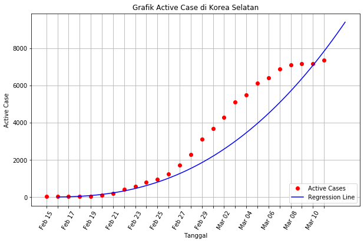

```python
korsel_ac_be_p = regresi_aktif_berpangkat(korsel, 'before', 'Mar 11')
```

```
=== Persamaan Regresi Berpangkat pada Active Cases setelah Mar 11 di Korea Selatan ===
            Persamaan Regresi = y = 160828.36684210374(x^(-0.9192919998747706))
            Koefisien Korelasi = 0.9519830496695035
```

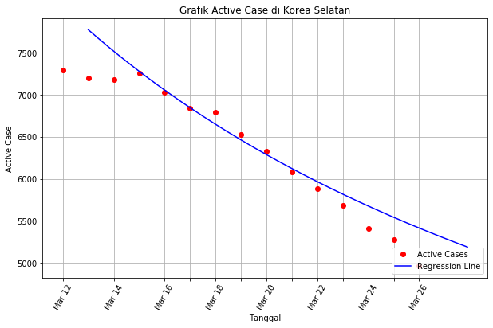

```python
korsel_ac_af_p = regresi_aktif_berpangkat(korsel, 'after', 'Mar 11')
```

### Persamaan Regresi Eksponensial pada Active Cases di Korea Selatan

```
Peringatan! terjadi keanehan data, sehingga koefisien korelasi lebih dari satu.
Oleh karena itu, batas digeser ke Mar 08
=== Persamaan Regresi Eksponensial pada Active Cases sebelum Mar 11 di Korea Selatan ===
            Persamaan Regresi = y = 17.2904e^(0.3081x)
            Koefisien Korelasi = 0.9832973505534026
```

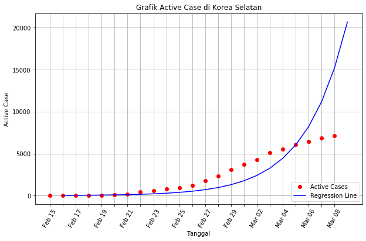

```python
korsel_ac_be_e = regresi_aktif_eksponensial(korsel, 'before', 'Mar 11')
```

```
=== Persamaan Regresi Eksponensial pada Active Cases setelah Mar 11 di Korea Selatan ===
            Persamaan Regresi = y = 16282.5330e^(-0.0278x)
            Koefisien Korelasi = 0.96766445245816
```

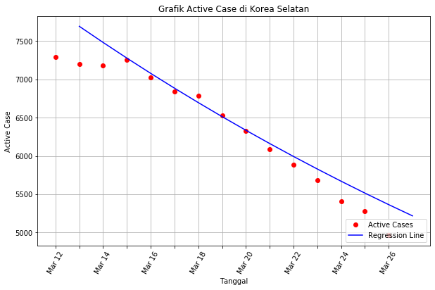

```python
korsel_ac_af_e = regresi_aktif_eksponensial(korsel, 'after', 'Mar 11')
```

### Persamaan Regresi Polinomial (orde 3) pada Active Cases di Korea Selatan

```
=== Persamaan Regresi Polinomial pada Active Cases sebelum Mar 11 di Korea Selatan ===
            Persamaan Regresi = y = 999.4408 + (-565.8759)x + (69.6722)x^2 + (-1.4701)x^3
            Koefisien Korelasi = 0.9956193385836315
```

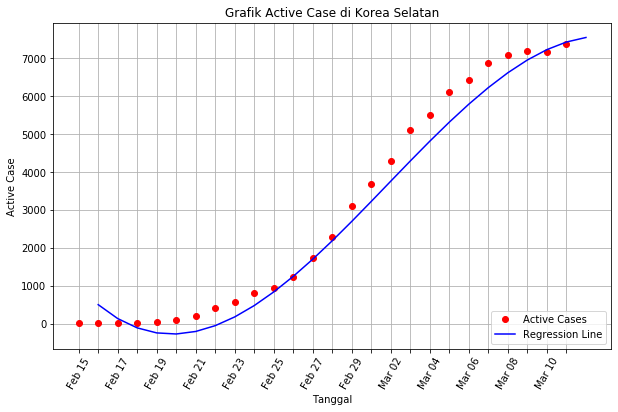

```python
korsel_ac_be_po = regresi_aktif_polinomial(korsel, 'before', 'Mar 11')
```

```
=== Persamaan Regresi Polinomial pada Active Cases setelah Mar 11 di Korea Selatan ===
            Persamaan Regresi = y = -2698.0061 + (885.7491)x + (-22.9187)x^2 + (0.1429)x^3
            Koefisien Korelasi = 0.9968768715243279
```

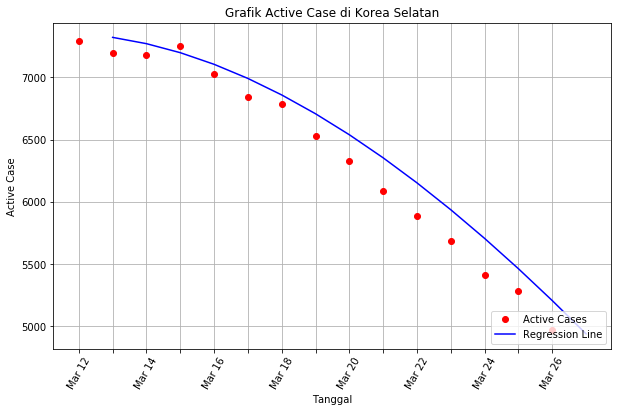

```python
korsel_ac_af_po = regresi_aktif_polinomial(korsel, 'after', 'Mar 11')
```

### Analisis kurva-kurva regresi pada Active Cases di Korea Selatan

```python
analisis('Active', korsel_ac_be_p, korsel_ac_be_e, korsel_ac_be_po, korsel_ac_af_p, korsel_ac_af_e, korsel_ac_af_po, '11 Maret')
```

```
=== Active Cases sebelum 11 Maret ===

        -Persamaan Regresi-
        Regresi Berpangkat: y = 2.58156288829746(x^(2.4909327586086443))
        Regresi Eksponensial: y = 17.2904e^(0.3081x)
        Regresi Polinomial orde 3: y = 999.4408 + (-565.8759)x + (69.6722)x^2 + (-1.4701)x^3

        -Koefisien Korelasi-
        Regresi Berpangkat: 0.9567
        Regresi Eksponensial: 0.9833
        Regresi Polinomial orde 3: 0.9956

=== Active Cases sesudah 11 Maret hinga 26 Maret 2020 ===

        -Persamaan Regresi-
        Regresi Berpangkat: y = 160828.36684210374(x^(-0.9192919998747706))
        Regresi Eksponensial: y = 16282.5330e^(-0.0278x)
        Regresi Polinomial orde 3:`b y = -2698.0061 + (885.7491)x + (-22.9187)x^2 + (0.1429)x^3

        -Koefisien Korelasi-
        Regresi Berpangkat: 0.9520
        Regresi Eksponensial: 0.9677
        Regresi Polinomial orde 3: 0.9969
```

Dari data diatas, dapat diambil kesimpulan bahwa kurva regresi polinomial orde 3 dapat mewakili data *active cases* di Korea Selatan.

```python
kurva_negara['korsel'] = {}
kurva_negara['korsel']['ac'] = korsel_ac_af_po
```

### Death Cases

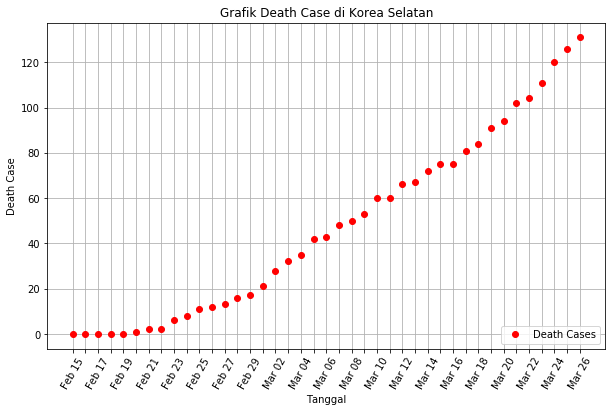

```python
plot_death_data(korsel)
```

Data naik secara konsisten sehingga regresi tidak perlu dibagi.

### Persamaan Regresi Berpangkat pada Death Cases di Korea Selatan

```
=== Persamaan Regresi Berpangkat pada Death Cases di Korea Selatan ===
        Persamaan Regresi = y = 0.14751964383902103(x^(1.8001506505982283))
        Koefisien Korelasi = 0.9864189860725365
```

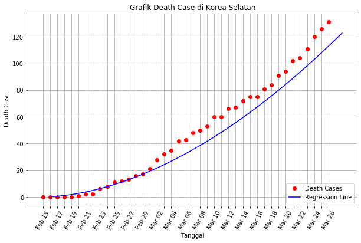

```python
korsel_dc_p = regresi_death_berpangkat(korsel)
```

### Persamaan Regresi Eksponensial pada Death Cases di Korea Selatan

```
=== Persamaan Regresi Eksponensial pada Death Cases di Korea Selatan ===
        Persamaan Regresi = y = 1.4804e^(0.1286x)
        Koefisien Korelasi = 0.3381198580553279
```

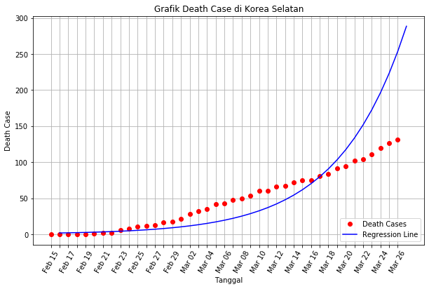

```python
korsel_dc_e = regresi_death_eksponensial(korsel)
```

### Persamaan Regresi Polinomial (orde 3) pada Death Cases di Korea Selatan

```
=== Persamaan Regresi Polinomial pada Death Cases di Korea Selatan ===
        Persamaan Regresi = y = -5.7704 + (1.0246)x + (0.0551)x^2 + (0.0000)x^3
        Koefisien Korelasi = 0.99728378726209
```

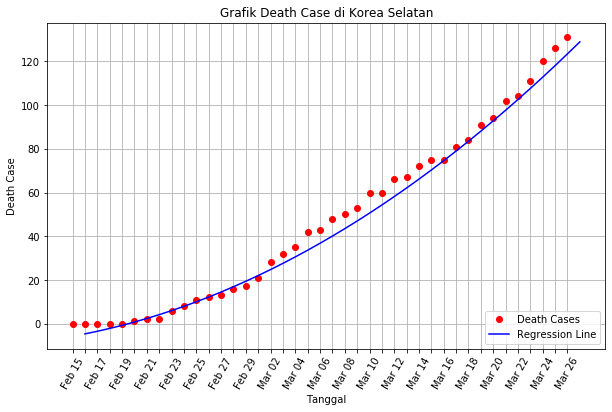

```python
korsel_dc_po = regresi_death_polinomial(korsel)
```

### Analisis kurva-kurva regresi pada Death Cases di Korea Selatan

```python
analisis('Death', korsel_dc_p, korsel_dc_e, korsel_dc_po)
```

```
=== Death Cases hingga 26 Maret 2020 ===

        -Persamaan Regresi-
        Regresi Berpangkat: y = 0.14751964383902103(x^(1.8001506505982283))
        Regresi Eksponensial: y = 1.4804e^(0.1286x)
        Regresi Polinomial orde 3: y = -5.7704 + (1.0246)x + (0.0551)x^2 + (0.0000)x^3

        -Koefisien Korelasi-
        Regresi Berpangkat: 0.9864
        Regresi Eksponensial: 0.3381
        Regresi Polinomial orde 3: 0.9973
```

Dari daftar di atas, dapat dilihat bahwa kurva regresi polinomial orde 3 paling mewakili untuk data death cases di korea selatan sampai 26 Maret 2020.

```python
kurva_negara['korsel']['dc'] = korsel_dc_po
```